# Client Profile System

Lana Zhang

2025-07-17

# 1 Introduction

In behavioral healthcare services, effective client engagement is critical to ensuring timely access to care and maximizing treatment outcomes. However, resource limitations often make it challenging to allocate outreach efforts equitably and efficiently. This project aims to develop a data-driven client prioritization framework to assist behavioral health agencies in identifying which clients might need more emotional support, who is more likely to respond quickly, and where to allocate resources efficiently.

# 2 Data Source

All client-level data were exported from the agency’s internal CRM (Client Relationship Management) system between January 1st and July 15th, 2025, covering active or referred cases during that period. A total of 100 synthetic client profiles were generated for the preliminary development and validation of our risk scoring framework, reflecting typical patterns encountered in public health service delivery.

All analyses were performed in R, with careful attention to imputation of missing values, model validation, and interpretability of results.

# 3 System Set Up

```r
library(tidyverse)
library(dplyr)
library(readxl) # read excel
library(mice) # missing data
library(knitr) # table
library(broom) # tidy frames
library(survival) # survival analysis
library(randomForest) # random forest analysis
library(boot) # cv.glm()
```

# 4 Data Wrangling

## 4.1 Input Data

```r
data_client <- read_excel("/Users/zyc/Projects/R/Client Profile Radar Map.xlsx", sheet = "Client Profile Row Data")
```

## 4.2 Data Cleaning

```r
# --- Duplicates ---
data_client <- head(data_client, -1) # Remove the last Row (NA)
data_client %>%
  distinct(Client_Name, .keep_all = TRUE) # Remove duplicates
data_client <- data_client[, c(1,3,5,7,9,11,13,15,17,19,21,23,25,26)] # Select score columns only

# --- Missing values ---
data_client[] <- lapply(data_client, function(x) if (is.character(x)) as.factor(x) else x)
# Perform multiple imputation using mice
imp_result <- mice(data_client, m = 5, method = "pmm", seed = 123) # predictive mean matching for continuous variables
# Extract the first imputed dataset
data_client <- complete(imp_result, 1)
```

# 5 Model Analysis

## 5.1 Feature Selection - Logistic Regression Analysis

To identify which behavioral factors are most strongly predict of enrollment success, we fitted a logistic regression model using all available 12 predictors and the estimated the log-odds of enrollment.

To avoid overfitting and reduce multicollinearity, we applied **stepwise feature selection** in both directions using **Akaike Information Criterion (AIC)** as the selection metric. After selection, we computed **odds ratios (ORs)**, representing the multiplicative change in the odds of enrollment associated with a one-unit increase in each predictor, holding others constant.

```r
# Logistic Regression Model
log_model <- glm(Outcome ~ Family_Complexity_Score + Language_Barrier_Score +
                   Emotional_Intensity_Score + Prior_Trauma_Score + Interest_Level_Score +
                   Responsiveness_Score + Scheduling_Flexibility_Score + Contact_Frequency_Score +
                   Insurance_Status_Score + Transportation_Barrier_Score + Digital_Access_Score +
                   Referral_Source_Score, data_client, family = binomial)

# Feature Selection
log_model_step <- step(log_model, direction = "both") # based on AIC

# Extract tidy summary from logistic model
or_table <- tidy(log_model_step, conf.int = TRUE, exponentiate = TRUE) %>%
  filter(term != "(Intercept)") %>%  # exclude intercept
  mutate(across(c(estimate, conf.low, conf.high, p.value), round, 4)) %>%
  rename(
    Variable = term,
    OR = estimate,
    `95% CI (Lower)` = conf.low,
    `95% CI (Upper)` = conf.high,
    `p-value` = p.value
  )
```

The final logistic regression model retained **seven key predictors**:

- Language_Barrier_Score
- Emotional_Intensity_Score
- Interest_Level_Score
- Responsiveness_Score
- Scheduling_Flexibility_Score
- Contact_Frequency_Score
- Transportation_Barrier_Score

The odds ratio table below presents the odds ratios, coefficients, confidence intervals, and p-values for each retained variable, preparing the foundation for the weighted scoring and outreach prioritization strategy introduced in subsequent sections.

```r
# Display the Odds Ratios result of Regression Analysis in Table
kable(or_table, caption = "Odds Ratios of Logistic Regression Model")
```

Odds Ratios of Logistic Regression Model

| Variable | OR | std.error | statistic | p-value | 95% CI (Lower) | 95% CI (Upper) |
| --- | --- | --- | --- | --- | --- | --- |
| Language_Barrier_Score | 0.5444 | 0.1850730 | -3.285661 | 0.0010 | 0.3674 | 0.7660 |
| Emotional_Intensity_Score | 0.6842 | 0.1814091 | -2.091758 | 0.0365 | 0.4699 | 0.9648 |
| Interest_Level_Score | 0.5524 | 0.1972014 | -3.009909 | 0.0026 | 0.3632 | 0.7946 |
| Responsiveness_Score | 0.6970 | 0.1859772 | -1.941247 | 0.0522 | 0.4740 | 0.9919 |
| Scheduling_Flexibility_Score | 0.7254 | 0.1754600 | -1.829979 | 0.0673 | 0.5051 | 1.0131 |
| Contact_Frequency_Score | 0.5032 | 0.2144360 | -3.202512 | 0.0014 | 0.3186 | 0.7452 |
| Transportation_Barrier_Score | 0.7089 | 0.1734836 | -1.983345 | 0.0473 | 0.4961 | 0.9876 |

## 5.2 Variable Importance Ranking - Random Forest Analysis

We used Random Forest to assess the relative importance of predictors for enrollment outcome. Variable importance was measured by the **mean decrease in Gini impurity**, the plot and table below highlight the top predictors, with higher Gini values indicating greater influence on model decisions, identifying which predictor most strongly drive successful engagement.

```r
# Random Forest Model
data_client$Outcome <- as.factor(data_client$Outcome) # Convert Outcome to factor
rf_model <- randomForest(Outcome ~ Family_Complexity_Score + Language_Barrier_Score +
                   Emotional_Intensity_Score + Prior_Trauma_Score + Interest_Level_Score +
                   Responsiveness_Score + Scheduling_Flexibility_Score + Contact_Frequency_Score +
                   Insurance_Status_Score + Transportation_Barrier_Score + Digital_Access_Score +
                   Referral_Source_Score, data = data_client, importance = TRUE)

# Print and plot feature importance
importance(rf_model)
```

```
##                                       0          1 MeanDecreaseAccuracy
## Family_Complexity_Score      -0.1088950 -1.9950921           -1.3204211
## Language_Barrier_Score        3.4998703  7.5311868            7.5576554
## Emotional_Intensity_Score     0.9553822  0.7677469            1.0296653
## Prior_Trauma_Score            1.1298398 -2.2007618           -0.9561984
## Interest_Level_Score          3.7612648  3.4406175            4.6128613
## Responsiveness_Score         -0.3851815  3.9625907            2.2174518
## Scheduling_Flexibility_Score -0.2479444  1.4805421            0.7539838
## Contact_Frequency_Score       4.3370046  2.1770056            4.5100279
## Insurance_Status_Score        1.7054683 -1.6718369            0.2061332
## Transportation_Barrier_Score  1.3913763  4.5562048            3.9441174
## Digital_Access_Score          0.4614077 -1.5561737           -0.6195368
## Referral_Source_Score         5.2645908 -0.7299442            3.7261679
##                              MeanDecreaseGini
## Family_Complexity_Score              3.082906
## Language_Barrier_Score               6.465041
## Emotional_Intensity_Score            3.858714
## Prior_Trauma_Score                   2.932388
## Interest_Level_Score                 4.355271
## Responsiveness_Score                 4.315252
## Scheduling_Flexibility_Score         3.673420
## Contact_Frequency_Score              4.244997
## Insurance_Status_Score               3.123512
## Transportation_Barrier_Score         4.569516
## Digital_Access_Score                 2.840232
## Referral_Source_Score                4.232941
```

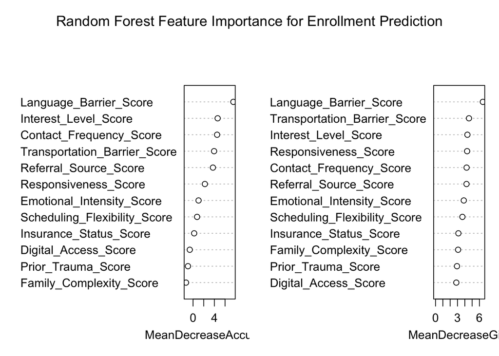

```r
varImpPlot(rf_model,  # Score weighted based on MeanDecreaseGini
           main = "Random Forest Feature Importance for Enrollment Prediction")
```

Among all variables, the top contributors by both metrics include:

- **Language_Barrier_Score** (Gini: 6.47; Accuracy Drop: 7.56)
- **Interest_Level_Score** (Gini: 4.36)
- **Transportation_Barrier_Score** (Gini: 4.57)
- **Contact_Frequency_Score** (Gini: 4.24)

In contrast, variables such as **Digital_Access_Score** and **Prior_Trauma_Score** exhibited low or even negative importance scores, suggesting minimal or noisy contributions to model performance.

## 5.3 Weighted Score System - ORs and Ginis Normalization

To build a client prioritization score (`Total_Score`), we constructed a hybrid weighting system based on:

- **Odds Ratios (OR)** from the logistic regression model, representing the strength of association between each predictor and the probability of successful enrollment.
- **MeanDecreaseGini (Gini Importance)** from the Random Forest model, reflecting the contribution of each variable to prediction accuracy and tree splits.

We applied **min-max normalization** to both metrics, then computed a weighted average using a 60% emphasis on logistic model interpretability and 40% on machine learning robustness. The final scores were normalized to sum to 1.

```r
# Input odds ratios and MeanDecreaseGini results
or_values <- c(
  Language_Barrier_Score       = 0.5443913,
  Emotional_Intensity_Score    = 0.6842281,
  Interest_Level_Score         = 0.5523583,
  Responsiveness_Score         = 0.6969597,
  Scheduling_Flexibility_Score = 0.7253593,
  Contact_Frequency_Score      = 0.5032169,
  Transportation_Barrier_Score = 0.7088738
)
gini_values <- c(
  Language_Barrier_Score        = 6.465041,
  Emotional_Intensity_Score     = 3.858714,
  Interest_Level_Score          = 4.355271,
  Responsiveness_Score          = 4.315252,
  Scheduling_Flexibility_Score  = 3.673420,
  Contact_Frequency_Score       = 4.244997,
  Transportation_Barrier_Score  = 4.569516
)

# Normalize using min-max scaling
or_score <- (or_values - min(or_values)) / (max(or_values) - min(or_values))
gini_score <- (gini_values - min(gini_values)) / (max(gini_values) - min(gini_values))

# Combine OR and Gini scores using weighted average
final_score <- 0.6 * or_score + 0.4 * gini_score
final_score <- final_score[c(
  "Language_Barrier_Score",
  "Emotional_Intensity_Score",
  "Interest_Level_Score",
  "Responsiveness_Score",
  "Scheduling_Flexibility_Score",
  "Contact_Frequency_Score",
  "Transportation_Barrier_Score"
)]

# Normalize sum to 1
normalized_weight <- final_score / sum(final_score)

# Calculate the Total_Score
selected_columns <- intersect(names(normalized_weight), colnames(data_client))
score_matrix <- as.matrix(data_client[, selected_columns])
data_client$Total_Score <- as.vector(score_matrix %*% normalized_weight)

# Display Weighted Score System
weight_table <- data.frame(
  Weight = round(normalized_weight, 4)
)
kable(weight_table, caption = "Final Weights Assigned to Predictors in the Total Score System")
```

Final Weights Assigned to Predictors in the Total Score System

|  | Weight |
| --- | --- |
| Language_Barrier_Score | 0.1579 |
| Emotional_Intensity_Score | 0.1592 |
| Interest_Level_Score | 0.0712 |
| Responsiveness_Score | 0.1900 |
| Scheduling_Flexibility_Score | 0.1853 |
| Contact_Frequency_Score | 0.0253 |
| Transportation_Barrier_Score | 0.2112 |

# 6 Model Validation

## 6.1 10-Fold Cross-validation

To evaluate the generalizability of the logistic regression model using the derived `Total_Score` as the predictor for client enrollment outcome, we applied 10-fold cross-validation using the `cv.glm` function from the `boot` package.

```r
# Cross-validation Model
model_cv <- glm(Outcome ~ Total_Score, data = data_client, family = binomial)
cv_result <- cv.glm(data_client, model_cv, K = 10) # 10-Fold

# Summary and display the Cross-validation Results in Table
cv_summary <- data.frame(
  Metric = c("Raw Prediction Error", "Bias-Corrected Error"),
  Value = round(cv_result$delta, 4)
)
kable(cv_summary, caption = "10-Fold Cross-Validation of Priority Score")
```

10-Fold Cross-Validation of Priority Score

| Metric | Value |
| --- | --- |
| Raw Prediction Error | 0.1787 |
| Bias-Corrected Error | 0.1783 |

The cross-validation results yielded a raw prediction error of **0.1787** and a bias-corrected error of **0.1783**, , indicating strong consistency and low variance across different data folds. This suggests that the model is not overfitting and exhibits stable predictive performance when applied to unseen data.

## 6.2 A/B Testing with Standard Deviation Banding

```r
# --- Standard Deviation Banding ---
# Calculate mean and standard deviation score
score_mean <- mean(data_client$Total_Score, na.rm = TRUE)
score_sd <- sd(data_client$Total_Score, na.rm = TRUE)

# Categorize clients into 3 priority groups based on Standard Deviation Banding
data_client$Group <- cut(data_client$Total_Score,
                         breaks = c(-Inf, score_mean - score_sd,
                                    score_mean + score_sd, Inf),
                         labels = c("Low", "Medium", "High"), # Priority
                         include.lowest = TRUE)
data_client$Outcome_Labeled <- factor(data_client$Outcome,
                                      levels = c(0, 1),
                                      labels = c("Not Enrolled", "Enrolled")) # 0 = Not Enrolled, 1 = Enrolled

# --- A/B Testing ---
# Create the contingency table for A/B Testing
table_ab <- table(Group = data_client$Group, Outcome = data_client$Outcome_Labeled)

# Perform chi-squared test to check for association
ab_test_result <- chisq.test(table_ab) # both variables (Group and Outcome) are categorical
print(ab_test_result)
```

```
##
##  Pearson's Chi-squared test
##
## data:  table_ab
## X-squared = 25.937, df = 2, p-value = 2.332e-06
```

```r
# Display the cross-tabulated result in Table
knitr::kable(as.data.frame.matrix(table_ab), caption = "Enrollment Outcome by Priority Level (SD-based)")
```

Enrollment Outcome by Priority Level (SD-based)

|  | Not Enrolled | Enrolled |
| --- | --- | --- |
| Low | 3 | 19 |
| Medium | 32 | 24 |
| High | 19 | 2 |

The table above shows the distribution of enrollment outcomes across these three groups. The chi-squared test for independence yielded a p-value of **2.332^{-6}**.

This suggests that the difference in enrollment success across the three priority groups is statistically significant. In other words, the priority score effectively differentiates clients by likelihood of enrollment.

# 7 Conclusion

This client profile system demonstrates a data-driven approach to optimizing outreach strategies in behavioral healthcare settings. By integrating statistical modeling (logistic regression), machine learning (random forest), and model validation techniques (cross-validation, A/B Testing), we constructed a weighted prioritization score that reliably differentiates clients based on their predicted likelihood of successful service enrollment.

The system not only highlights which behavioral and logistical dimensions most influence engagement but also enables resource-limited agencies to stratify their outreach efforts with transparency and evidence. Future applications may include real-time client risk monitoring, automated decision dashboards, and continuous model recalibration as new data becomes available.

Ultimately, this client progile system advances both efficiency and equity in healthcare services, ensuring that those with the greatest urgency or likelihood of engagement are reached in a timely and personalized manner.